# ggplot2::geom_tile

Function of the Week

Author

Sanya Surya

Published

March 6, 2025

# 1 geom_tile()

In this document, I will introduce the geom_tile() function and show what it’s for.

```r
# Loading tidyverse and other libraries
pacman::p_load(
  tidyverse,
  readxl,
  ggthemes,
  ggplot2,
  here
  )
```

## 1.1 What is it for?

- This function comes from the ggplot2 library and is used for data visualization, specifically in the form of heatmaps or other tile plots.
- Heatmaps are a useful visual way to show the intensity of a numerical variable in the context of two categorical variables.
- In the code below, I will show how geom_tile() can be used to create a heatmap looking at a data set of HIV Diagnoses and AIDS Deaths in Oregon from 2012 to 2022. We will be looking at the count of cases of these indicators.
- *Data Source: Retrieved from CDC.gov.*
- *To get a CSV file, which I converted to an Excel file, I chose STI data in the form of a table and specified parameters: Indicators: AIDS Deaths, HIV Diagnoses, Age: 13+, Sex: Both, State: Oregon, Years: 2012-2022, All transmission categories, All races and ethnicities.*

```r
# Load and view the STI Dataset
# Skip the first 11 lines to reach the headers
OR_STI <- read_excel(here("function_week", "data", "data_SURYA.xlsx"), sheet = 1, skip = 11, na = "NA")
OR_STI
```

```
# A tibble: 22 × 4
   Indicator     Year                     Cases `Rate per 100000`
   <chr>         <chr>                    <dbl>             <dbl>
 1 AIDS deaths   2022                       140               3.8
 2 HIV diagnoses 2022                       250               6.8
 3 AIDS deaths   2021                       117               3.2
 4 HIV diagnoses 2021                       201               5.5
 5 AIDS deaths   2020 (COVID-19 Pandemic)   102               2.8
 6 HIV diagnoses 2020 (COVID-19 Pandemic)   180               4.9
 7 AIDS deaths   2019                       105               2.9
 8 HIV diagnoses 2019                       198               5.5
 9 HIV diagnoses 2018                       227               6.4
10 AIDS deaths   2018                        88               2.5
# ℹ 12 more rows
```

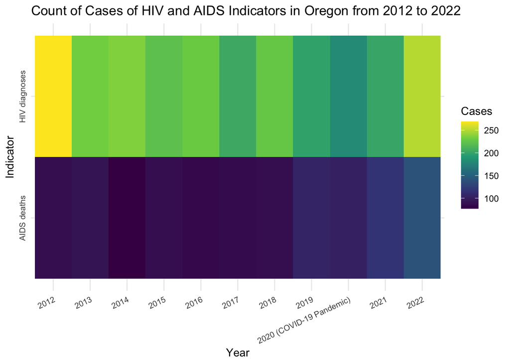

```r
# Create the heatmap
myplot <- ggplot(OR_STI,
       aes(x = Year,
           y = Indicator,
           fill = Cases)) +
  geom_tile() +
  scale_fill_viridis_c() +
  theme_minimal() +
  # Customize the angle and positions of x and y tick mark labels for better visualization (especially because the 2020 label has a much longer name)
  theme(axis.text.y = element_text(angle = 90, size = 8, hjust = 0.5),
        axis.text.x = element_text(angle = 25, hjust = 1, vjust = 1, size = 8)) +
  # Add a graph title
  labs(title = "Count of Cases of HIV and AIDS Indicators in Oregon from 2012 to 2022")
myplot
```

## 1.2 Is it helpful?

- Heatmaps are helpful to visualize categorical variables with a third numeric variable
- When there is a greater range of values, such as in this dataset, heatmaps can show intensity in an easy-to-digest visual way as opposed to other options where readers would need to read numeric scales on a graph.
- Can be helpful to visually stack and compare variables. In this data for instance, we can visually see that there have historically been a lot more HIV diagnoses than AIDS deaths, and HIV diagnoses fluctuate often with time. However, in recent years we can see a clear upward trend in counts of AIDS deaths since the color becomes lighter, indicating increasing cases.